# EDA Sense8

## Qual das séries que você escolheu tem episódios de qualidade mais irregular segundo o IMDB? A diferença é grande? Pequena?

O que podemos observar é que, ‘Thundercats’apresentou inicialmente uma maior irregularidade nas avaliações das suas primeiras temporadas, podemos observar que o gráfico apresenta vários picos, tanto negativos como positivos com o decorrer dos episódios, chegando a ter uma diferença de mais de 2 pontos de um episódio para outro dentro de uma mesma temporada, porém essas diferenças foram diminuindo mais próximo do fim da série apresentando uma diferença de pouco mais de meio ponto. Ja em ’Xena’ ocorre o contrário, nas 3 primeiras temporadas a diferença é menor entre a qualidade dos episódio e quando observamos as avaliações da 4ª temporada em diante os dados começam a apresentar uma variação mais acentuada, chegando a ter mais de 2 pontos de diferença em episódios em uma única temporada.

> > Os dois plots abaixo são apenas sugestões de visualização, por isso, não inclui interpretação para eles no texto

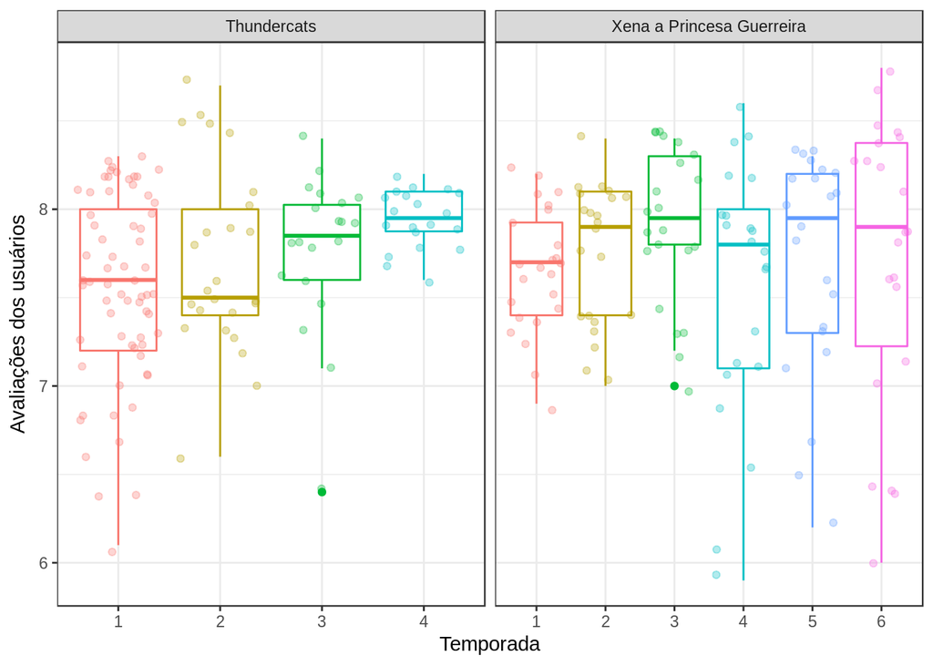

```r
episodes %>%
    ggplot(aes(x = season, y = user_rating, color = season)) +
    geom_boxplot() +
    geom_jitter(alpha = 0.3) +
    facet_wrap(~series_name, scales = "free_x") +
    theme(legend.position="none") +
    labs(x = "Temporada", y = "Avaliações dos usuários")
```

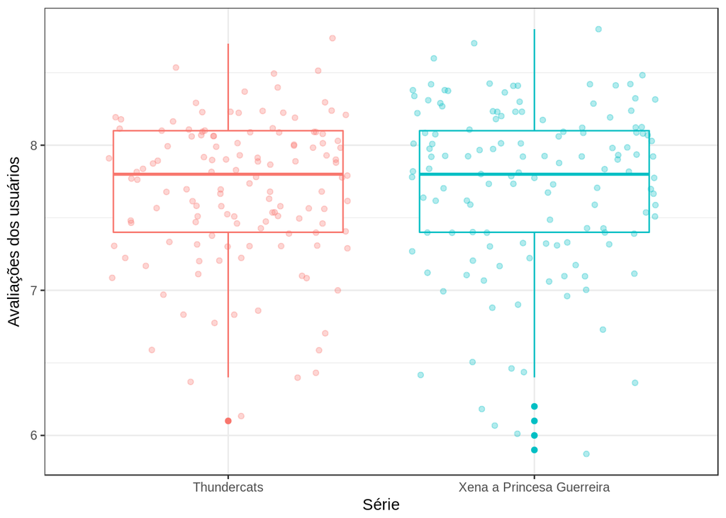

```r
episodes %>%
    ggplot(aes(x = series_name, y = user_rating, color = series_name)) +
    geom_boxplot() +
    geom_jitter(alpha = 0.3) +
    theme(legend.position="none") +
    labs(x = "Série", y = "Avaliações dos usuários")
```

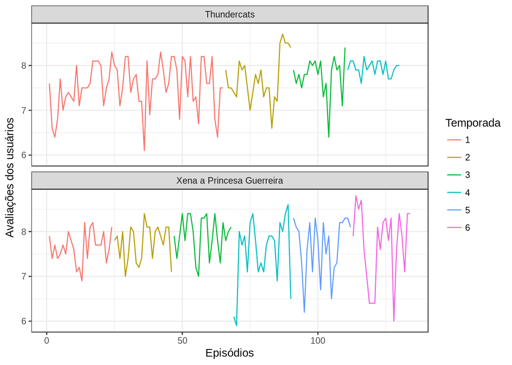

```r
episodes %>%
    ggplot(aes(x = series_ep, y = user_rating, color = season)) +
    labs(x = "Episódios", y = "Avaliações dos usuários") +
    geom_line() + facet_wrap(~ series_name, ncol = 1)+
    guides(color = guide_legend("Temporada"))
```

Para termos uma análise mais exata da variação das avaliações para cada série, abaixo calculamos o coeficiente de variância para cada uma. Percebe-se que ‘Xena’ tem uma variação um pouco maior para cada episódio.

```r
episodes %>% group_by(series_name) %>%
    summarise(coef_var = (sd(user_rating)/mean(user_rating)) * 100)
```

| series_name | coef_var |
| --- | --- |
| Thundercats | 6.415064 |
| Xena a Princesa Guerreira | 7.616969 |

## Quantas avaliações temos por episódio?

Cada episódio foi avaliado por um número diferente de usuários do IMDB. Vejamos como é essa distribuição.

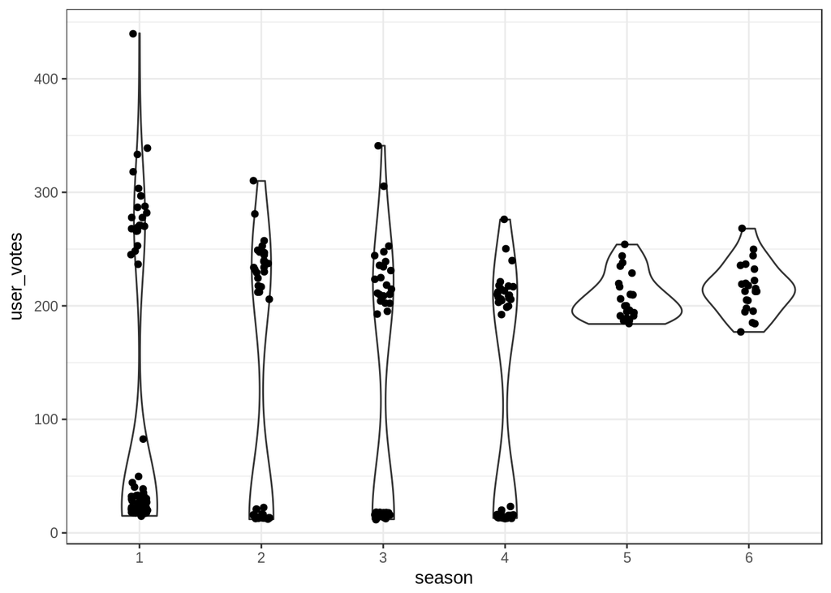

```r
episodes %>%
    ggplot(aes(x = season, y = user_votes)) +
    geom_violin() +
    geom_jitter(width = .07)
```

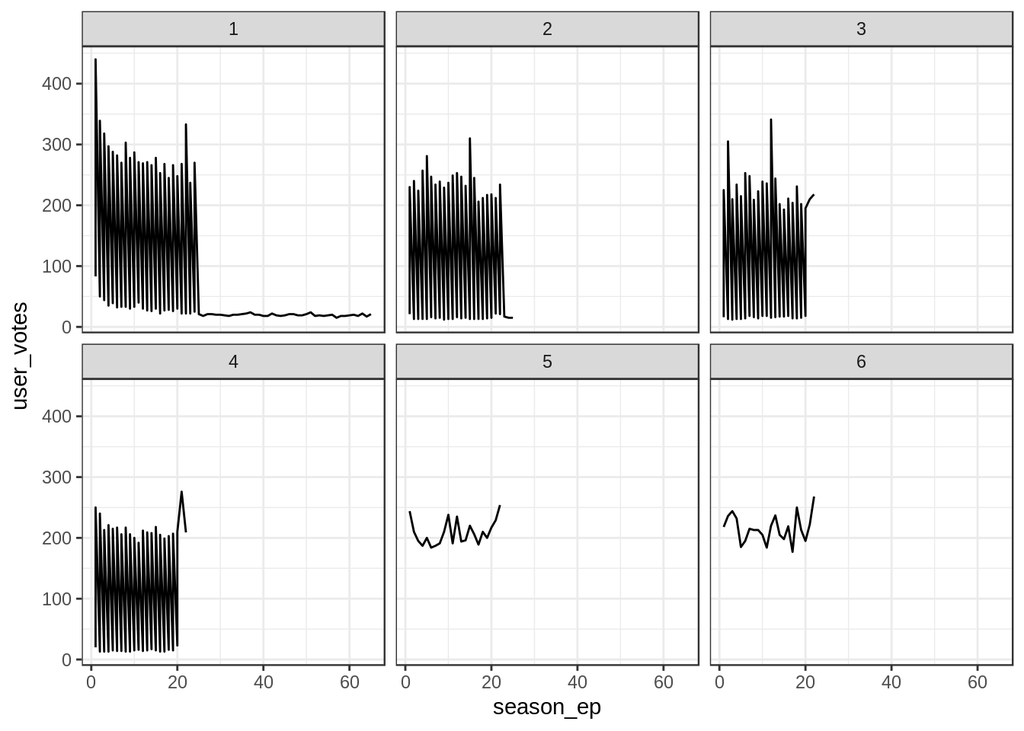

```r
episodes %>%
    ggplot(aes(x = season_ep, y = user_votes))  +
    geom_line() +
    facet_wrap(~ season)
```

## Qual a distribuição da avaliação dos episódios?

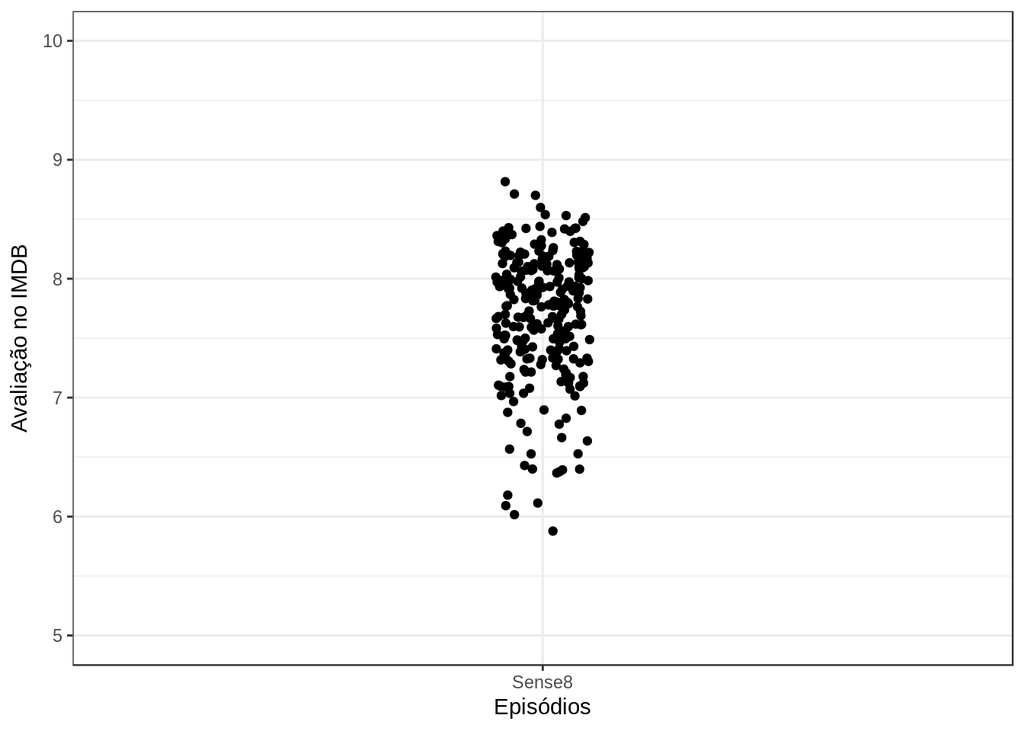

```r
episodes %>%
    ggplot(aes(x = "Sense8", y = user_rating)) +
    geom_jitter(width = .05) +
    ylim(5, 10) +
    labs(x = "Episódios", y = "Avaliação no IMDB")
```

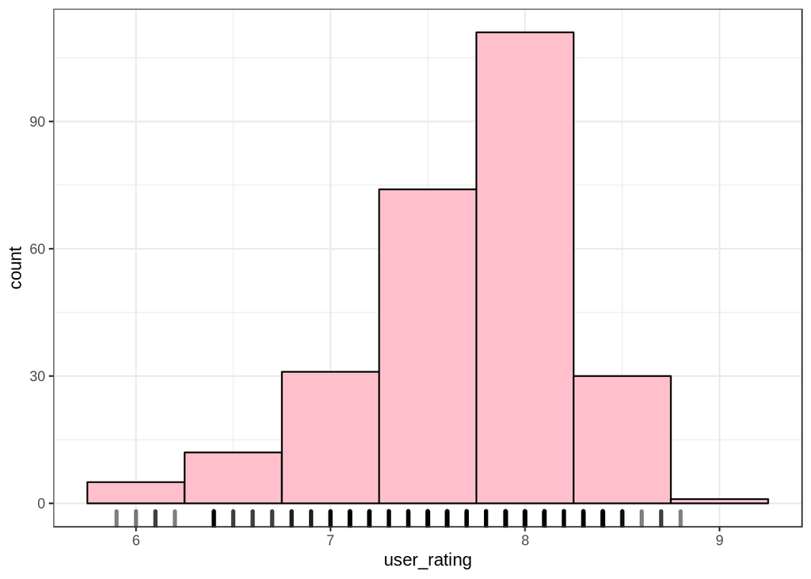

```r
episodes %>%
    ggplot(aes(x = user_rating)) +
    geom_histogram(binwidth = .5, fill = "pink", color = "black") +
    geom_rug(alpha = .5, size = 1.2)
```

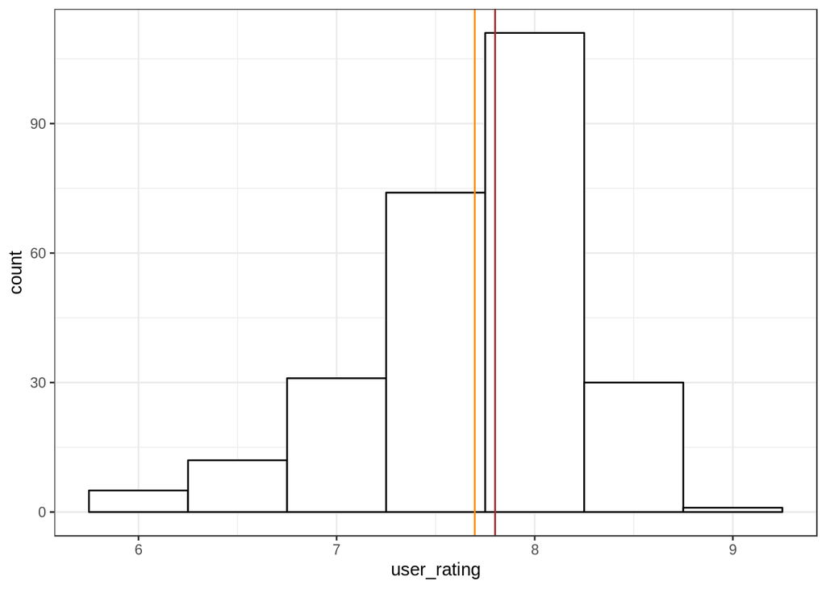

```r
sumarios = episodes %>%
    summarise(mediana = median(user_rating),
              media = mean(user_rating))

episodes %>%
    ggplot(aes(x = user_rating)) +
    geom_histogram(binwidth = .5, fill = "white", color = "black") +
    geom_vline(xintercept = sumarios$media, color = "darkorange") +
    geom_vline(xintercept = sumarios$mediana, color = "brown")
```

### Qual é esse episódio pior avaliado?

```r
episodes %>%
    filter(user_rating == min(user_rating))
```

| series_name | episode | series_ep | season | season_ep | url | user_rating | user_votes | r1 | r2 | r3 | r4 | r5 | r6 | r7 | r8 | r9 | r10 |
| --- | --- | --- | --- | --- | --- | --- | --- | --- | --- | --- | --- | --- | --- | --- | --- | --- | --- |
| Xena a Princesa Guerreira | Adventures in the Sin Trade II | 70 | 4 | 2 | http://www.imdb.com/title/tt0751509/ | 5.9 | 240 | 0.1136364 | 0.05454545 | 0.06363636 | 0.06363636 | 0.09090909 | 0.1 | 0.1045455 | 0.06818182 | 0.06363636 | 0.2772727 |

## Qual a pior/melhor temporada segundo o IMDB?

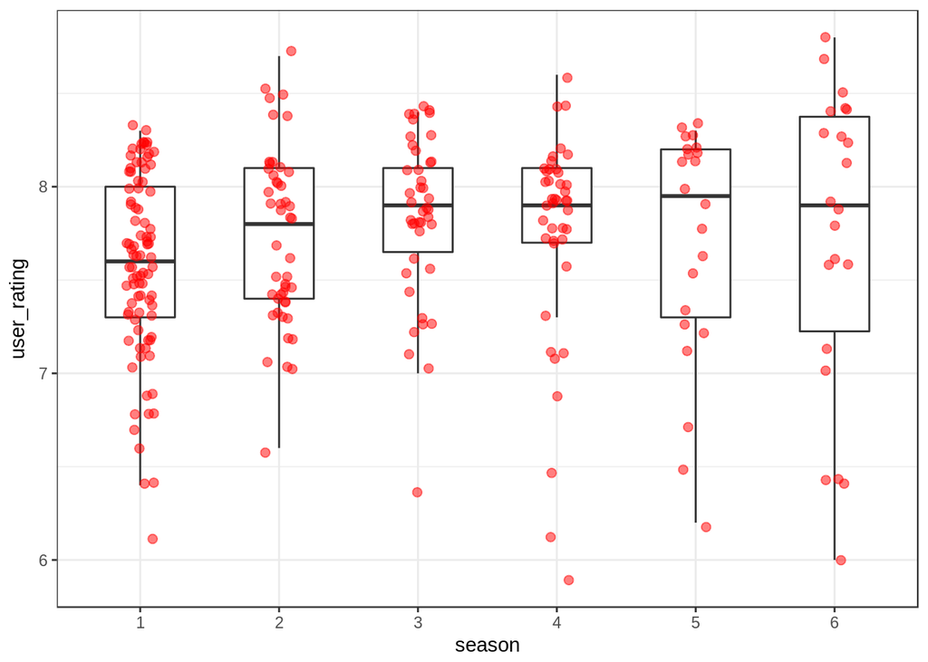

```r
episodes %>%
    ggplot(aes(x = season, y = user_rating)) +
    geom_boxplot(width = .5, outlier.color = NA) +
    geom_jitter(width = .1, size = 2, alpha = .5, color = "red")
```

### Há padrões na avaliação ao longo do tempo?

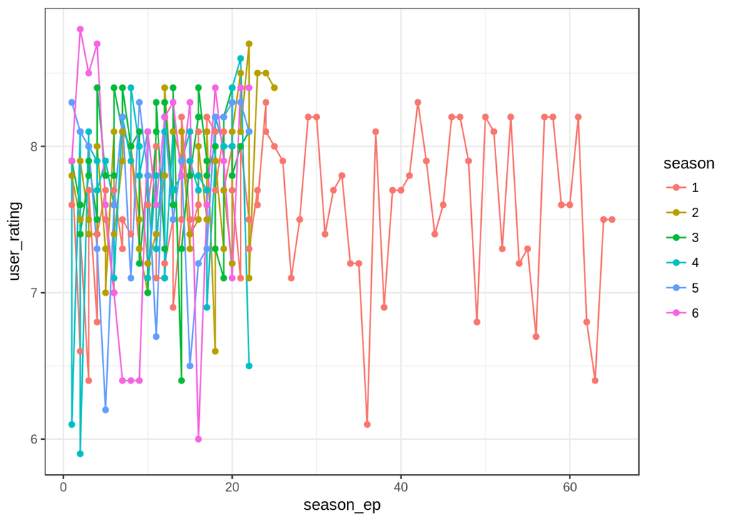

```r
episodes %>%
  ggplot(aes(x = season_ep, y = user_rating, color = season)) +
  geom_line() +
  geom_point()
```

Correlações

```r
episodes %>%
    group_by(season) %>%
    summarise(correlacao_linear = cor(season_ep, user_rating,
                                      method = "pearson"),
              correlacao_kendall = cor(season_ep, user_rating,
                                       method = "kendall"))
```

| season | correlacao_linear | correlacao_kendall |
| --- | --- | --- |
| 1 | 0.07928360 | 0.12273834 |
| 2 | 0.27828056 | 0.18020464 |
| 3 | 0.01214241 | 0.06256892 |
| 4 | 0.19020699 | 0.08838855 |
| 5 | 0.15095676 | 0.11166168 |
| 6 | 0.00886413 | 0.01774364 |

## Qual o episódio mais detestado?

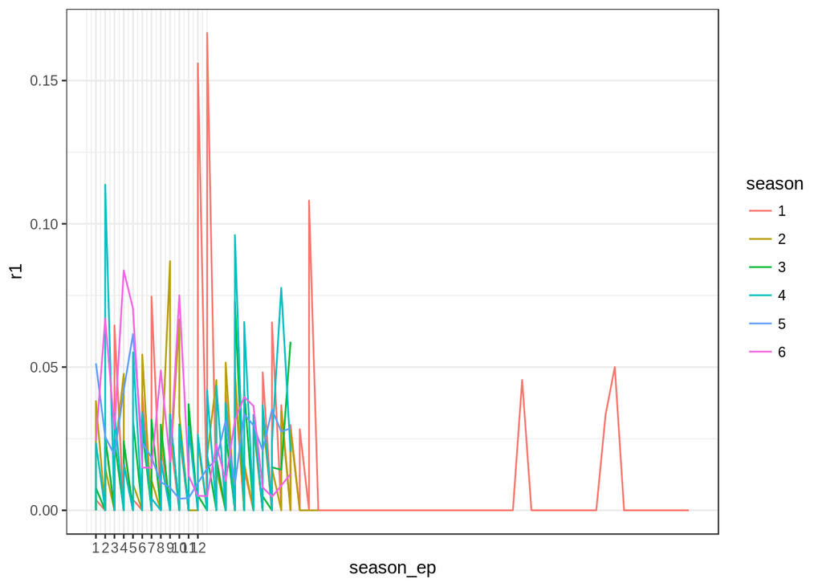

```r
episodes %>%
    ggplot(aes(x = season_ep, y = r1, color = season)) +
    geom_line() +
    scale_x_continuous(breaks = 1:12)
```

### E amado?

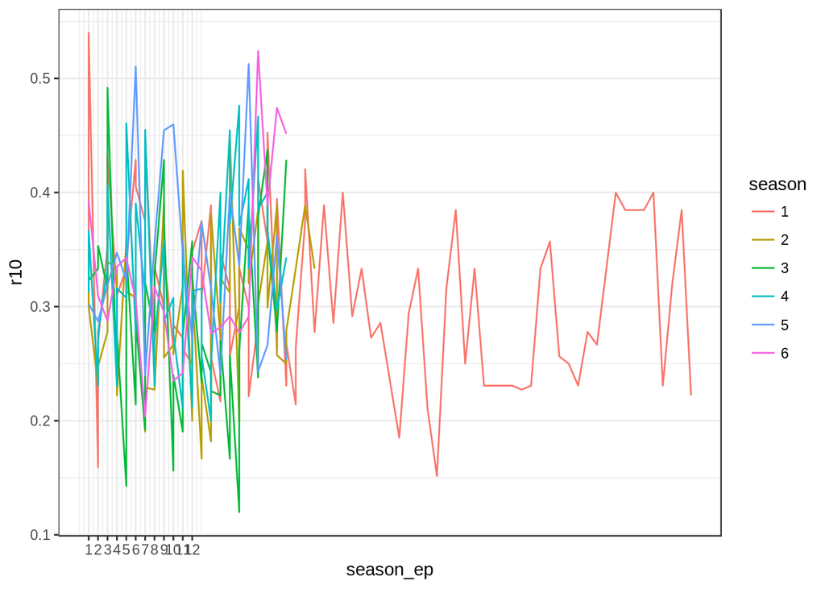

```r
episodes %>%
    ggplot(aes(x = season_ep, y = r10, color = season)) +
    geom_line() +
    scale_x_continuous(breaks = 1:12)
```

### Amor e ódio andam juntos?

Quais são episódios que estão entre os mais amados e mais odiados?

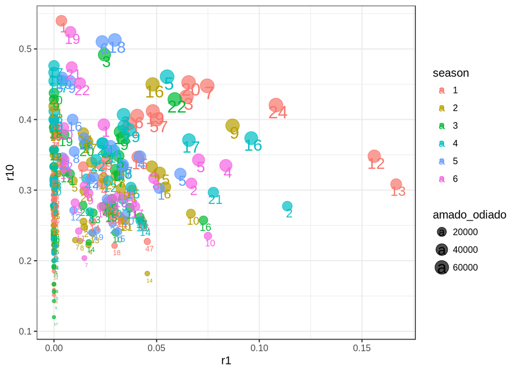

```r
episodes =  episodes %>%
    mutate(
        rank_odiados = row_number(r1), # maior = mais odiado
        rank_amados = row_number(r10), # maior = mais amado
        amado_odiado = rank_amados * rank_odiados) # maior = mais amado E odiado

episodes %>%
    ggplot(aes(
        x = r1,
        y = r10,
        color = season,
        size = amado_odiado,
        label = season_ep
    )) +
    geom_point(alpha = .7) +
    geom_text(nudge_x = .001, nudge_y = -.01)
```

```r
episodes %>%
    arrange(-amado_odiado)
```

| series_name | episode | series_ep | season | season_ep | url | user_rating | user_votes | r1 | r2 | r3 | r4 | r5 | r6 | r7 | r8 | r9 | r10 | rank_odiados | rank_amados | amado_odiado |
| --- | --- | --- | --- | --- | --- | --- | --- | --- | --- | --- | --- | --- | --- | --- | --- | --- | --- | --- | --- | --- |
| Xena a Princesa Guerreira | The Titans | 7 | 1 | 7 | http://www.imdb.com/title/tt0751445/ | 7.5 | 270 | 0.074626866 | 0.02985075 | 0.014925373 | 0.014925373 | 0.029850746 | 0.04850746 | 0.05597015 | 0.08582090 | 0.19776119 | 0.4477612 | 255 | 248 | 63240 |
| Xena a Princesa Guerreira | Is There a Doctor in the House? | 24 | 1 | 24 | http://www.imdb.com/title/tt0751462/ | 8.1 | 270 | 0.108108108 | 0.03303303 | 0.000000000 | 0.012012012 | 0.009009009 | 0.03603604 | 0.08408408 | 0.11711712 | 0.18018018 | 0.4204204 | 261 | 242 | 63162 |
| Xena a Princesa Guerreira | A Good Day | 73 | 4 | 5 | http://www.imdb.com/title/tt0751512/ | 7.9 | 215 | 0.055118110 | 0.01968504 | 0.015748031 | 0.019685039 | 0.011811024 | 0.03149606 | 0.09448819 | 0.14566929 | 0.14566929 | 0.4606299 | 245 | 256 | 62720 |
| Xena a Princesa Guerreira | Ties That Bind | 20 | 1 | 20 | http://www.imdb.com/title/tt0751458/ | 7.7 | 248 | 0.065573770 | 0.03278689 | 0.022950820 | 0.022950820 | 0.016393443 | 0.04262295 | 0.07868852 | 0.16393443 | 0.10163934 | 0.4524590 | 249 | 251 | 62499 |
| Xena a Princesa Guerreira | Dreamworker | 3 | 1 | 3 | http://www.imdb.com/title/tt0751441/ | 7.7 | 318 | 0.064516129 | 0.03548387 | 0.029032258 | 0.022580645 | 0.019354839 | 0.03870968 | 0.05161290 | 0.13548387 | 0.17096774 | 0.4322581 | 248 | 246 | 61008 |
| Xena a Princesa Guerreira | Sacrifice II | 68 | 3 | 22 | http://www.imdb.com/title/tt0751507/ | 8.1 | 218 | 0.058823529 | 0.03361345 | 0.033613445 | 0.037815126 | 0.042016807 | 0.06302521 | 0.10084034 | 0.08823529 | 0.11344538 | 0.4285714 | 246 | 245 | 60270 |
| Xena a Princesa Guerreira | For Him the Bell Tolls | 40 | 2 | 16 | http://www.imdb.com/title/tt0751478/ | 8.0 | 245 | 0.048034934 | 0.03056769 | 0.000000000 | 0.004366812 | 0.021834061 | 0.04803493 | 0.09170306 | 0.17030568 | 0.13537118 | 0.4497817 | 238 | 249 | 59262 |
| Thundercats | The Mad Bubbler | 74 | 2 | 9 | http://www.imdb.com/title/tt0922820/ | 7.5 | 12 | 0.086956522 | 0.00000000 | 0.000000000 | 0.000000000 | 0.043478261 | 0.00000000 | 0.21739130 | 0.13043478 | 0.13043478 | 0.3913043 | 259 | 228 | 59052 |
| Xena a Princesa Guerreira | Altared States | 19 | 1 | 19 | http://www.imdb.com/title/tt0751457/ | 7.7 | 266 | 0.048128342 | 0.01604278 | 0.026737968 | 0.042780749 | 0.053475936 | 0.11764706 | 0.08556150 | 0.14438503 | 0.05347594 | 0.4117647 | 239 | 240 | 57360 |
| Thundercats | Out of Sight | 57 | 1 | 57 | http://www.imdb.com/title/tt0922803/ | 8.2 | 15 | 0.050000000 | 0.00000000 | 0.000000000 | 0.000000000 | 0.100000000 | 0.10000000 | 0.15000000 | 0.10000000 | 0.10000000 | 0.4000000 | 241 | 232 | 55912 |

[output cut: 254 more lines]